# M2.859 - Visualización de datos aula 1

# **A5: Estudio de técnicas de visualización de datos (PEC2)**

Andres Ricardo Sanabria Garay

Mayo 2023

# Técnica de visualización Spiral Chart

## Contenido

- Descripción
- Origen
- Funcionamiento
- Ejemplo de aplicación
- Conclusión

# 1 Descripción

Es una forma de representar datos temporales a lo largo de una espiral. El gráfico comienza en el centro de la espiral y luego avanza hacia afuera. Los datos se pueden mostrar como barras, líneas o puntos a lo largo del camino espiral. Los gráficos espirales son ideales para mostrar grandes conjuntos de datos, generalmente para mostrar tendencias a lo largo de un gran período de tiempo. Por lo tanto, los gráficos espirales son excelentes para mostrar patrones periódicos. Se puede asignar un color a cada período para diferenciarlos y permitir alguna comparación entre cada período.

# 2 Origen

El origen de esta técnica de visualización se remonta a la antigua Grecia, donde se conocían varios tipos de espirales. En particular, la espiral de Arquímedes, una curva que se aleja del centro a medida que gira alrededor de él, fue descubierta por Conon de Samos en el año 320 a.C. y usada por Arquímedes en sus investigaciones matemáticas. Sin embargo, la aplicación de la espiral de Arquímedes a la visualización de datos temporales es más reciente y se atribuye a John V. Carlis y Joseph A. Konstan, quienes publicaron un artículo en 1998 titulado “Interactive Visualization of Serial Periodic Data” donde presentaron el concepto de gráfico espiral. Posteriormente, otros autores han desarrollado y mejorado esta técnica, como Marc Weber, Marc Alexa y Wolfgang Müller, quienes publicaron otro artículo en 2001 titulado “Visualizing Time-Series on Spirals” donde introdujeron algunas variaciones y optimizaciones del gráfico espiral

# 3 Funcionamiento

Se traza un eje temporal a lo largo de una espiral que comienza en el centro y luego se extiende hacia afuera. Cada vuelta de la espiral representa un período de tiempo, como un año, un mes o un día. Los datos se pueden mostrar como barras, líneas o puntos a lo largo del eje espiral, y se puede asignar un color a cada período para diferenciarlos y permitir alguna comparación entre ellos. La ventaja de esta técnica es que permite visualizar grandes conjuntos de datos y mostrar patrones periódicos o tendencias a lo largo del tiempo.

# 4 Ejemplo de aplicación

Aplicaremos esta técnica sobre uno de los conjuntos de datos disponibles en kaggle para un dataset llamado: Traffic Accidents in Arizona, especificamente con el archivo: accident.csv, publicado por: Sarah Cohen y que se encuentra disponible en el siguiente enlace:

https://www.kaggle.com/datasets/thedevastator/fatal-traffic-accidents-in-arizona-2012-2016?select=accident.csv

El objetivo es intentar identificar si existe algún patrón temporal en los accidentes, empleamos como referencia el trabajo plasmado en el siguiente sitio web:

https://flowingdata.com/2022/01/10/a-quick-and-easy-way-to-make-spiral-charts-in-r/

```r
# Cargamos las librerías que utilizaremos

if(!require(spiralize)){
    install.packages('spiralize', repos='http://cran.us.r-project.org')
    library(spiralize)
}
```

[output not shown]

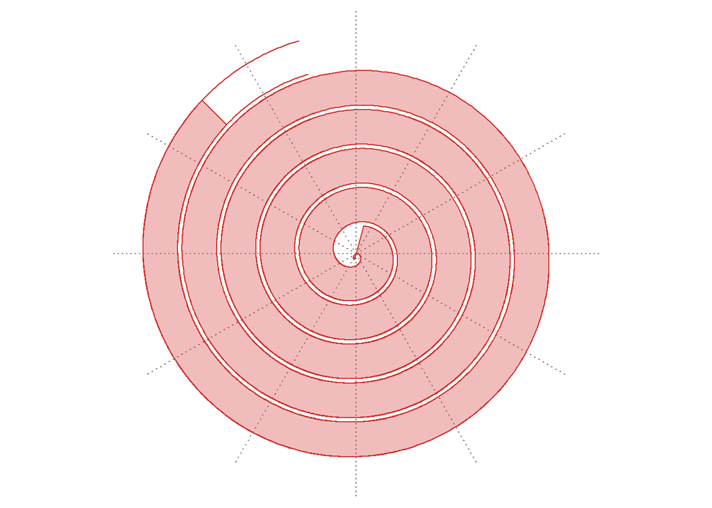

```r
# Cargamos el conjunto de datos
datos <- read.csv("accident.csv", stringsAsFactors = FALSE)

# Crear una nueva columna "fecha_hora" utilizando las columnas "dia", "mes" y "año"
datos$fecha_hora <- as.POSIXct(paste(datos$YEAR, datos$MONTH, datos$DAY, sep = "-"), format = "%Y-%m-%d")

datos$dt <- strptime(datos$fecha_hora, format="%Y-%m-%d")

ymax <- max(datos$accident_id)

# Initialize.
spiral_initialize_by_time(xlim=c("2012-01-01 00:00:00", "2016-12-31 00:00:00"),
                          unit_on_axis = "months", period="years",
                          start=90, end=(709/365)*360+(28/365)*360+90,
                          flip="horizontal")
# Create the track.
spiral_track(ylim=c(0, ymax*.9),
             background=FALSE, background_gp = gpar(col = NA, fill = NA))



# Use a polygon.
spiral_polygon(x=c(datos$dt, rev(datos$dt)),
               y=c(datos$accident_id/2, -rev(datos$accident_id/2)),
               gp = gpar(col="#d32e2b", fill="#d32e2b50"))
```

# 5 Conclusión

Luego de varios intentos se ha conseguido realizar una aproximación a la generación de un spiral chart. Sin embargo, algunos aspectos clave como el grosor del espiral que permita identificar las variaciones de accidentes aún está pendiente y esta es una característica clave para identificar patrones temporales.